# Analysis of relationships in pulmonary data

This program assesses the relationships among variables in a study of pulmonary function in children. There is a [data dictionary](https://github.com/pmean/datasets/blob/master/fev.yaml) that provides more details about the data. The program was written by Steve Simon on 2024-09-07 and is placed in the public domain.

## Libraries

```r
library(tidyverse)
```

#### Comments on the code

The tidyverse set of libraries are the only ones you need for this program.

## List variable names

```r
pulmonary_names <- c(
    "age",
    "fev",
    "ht",
    "sex",
    "smoke")
```

#### Comments on the code

Since the variable names are not listed in the data file itself, you need to list them here.

## Reading the data

Here is the code to read the data and show a glimpse.

```r
pulmonary <- read_csv(
  file="../data/fev.csv",
  col_names=pulmonary_names,
  col_types="nnncc")
glimpse(pulmonary)
```

```
Rows: 654
Columns: 5
$ age   <dbl> 9, 8, 7, 9, 9, 8, 6, 6, 8, 9, 6, 8, 8, 8, 8, 7, 5, 6, 9, 9, 5, 5…
$ fev   <dbl> 1.708, 1.724, 1.720, 1.558, 1.895, 2.336, 1.919, 1.415, 1.987, 1…
$ ht    <dbl> 57.0, 67.5, 54.5, 53.0, 57.0, 61.0, 58.0, 56.0, 58.5, 60.0, 53.0…
$ sex   <chr> "F", "F", "F", "M", "M", "F", "F", "F", "F", "F", "F", "M", "F",…
$ smoke <chr> "N", "N", "N", "N", "N", "N", "N", "N", "N", "N", "N", "N", "N",…
```

#### Comments on the code

Here is the code to read the data and show a glimpse. The col_names argument allows you to specify the names. The col_types argument here tells R that the first three columns are numeric and the last two columns are character (string).

## Calculate mean, standard deviation for fev

```r
pulmonary |>
  summarize(
    fev_mean=mean(fev),
    fev_stdv=sd(fev))
```

```
# A tibble: 1 × 2
  fev_mean fev_stdv
     <dbl>    <dbl>
1     2.64    0.867
```

#### Interpretation of the output

The mean fev is 2.6 liters and the standard deviation is 0.87 liters. I am not an expert on pulmonary function, but these values do not appear to be unusually large or small.

## Calculate mean, standard deviation for age

```r
pulmonary |>
  summarize(
    age_mean=mean(age),
    age_stdv=sd(age))
```

```
# A tibble: 1 × 2
  age_mean age_stdv
     <dbl>    <dbl>
1     9.93     2.95
```

#### Interpretation of the output

The mean age is 9.9 years. The youngest subject is 3 years old and the oldest is 19. This is consistent with a pediatric population.

## Calculate counts for smoke

```r
pulmonary |>
  count(smoke) |>
  mutate(total=sum(n)) |>
  mutate(pct=round(100*n/total))
```

```
# A tibble: 2 × 4
  smoke     n total   pct
  <chr> <int> <int> <dbl>
1 N       589   654    90
2 Y        65   654    10
```

Almost all of the subjects (90% or 589 out of 654) were non-smokers.

## Plot age versus fev

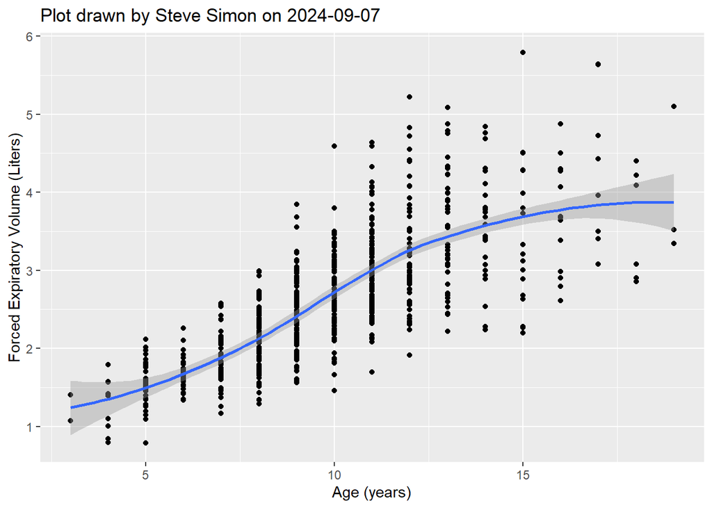

```r
pulmonary |>
  ggplot(aes(age, fev)) +
    geom_point() +
    geom_smooth() +
    xlab("Age (years)") +
    ylab("Forced Expiratory Volume (Liters)") +
    ggtitle("Plot drawn by Steve Simon on 2024-09-07")
```

## Correlation between age and fev

```r
cor(pulmonary$age, pulmonary$fev)
```

```
[1] 0.756459
```

The correlation, 0.75, and the plot both show a strong positive association between age and fev.

## Plot smoke versus fev

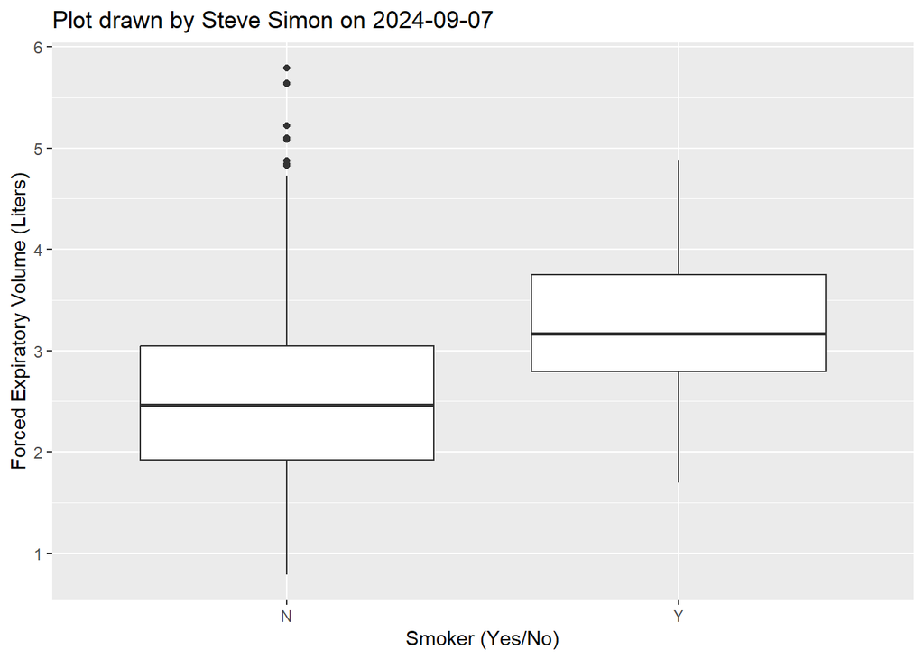

```r
pulmonary |>
  ggplot(aes(smoke, fev)) +
    geom_boxplot() +
    xlab("Smoker (Yes/No)") +
    ylab("Forced Expiratory Volume (Liters)") +
    ggtitle("Plot drawn by Steve Simon on 2024-09-07")
```

The fev values are larger for smokers versus non-smokers. This is the opposite direction from what we expected.

## Means and standard deviations for smokers and non-smokers.

```r
pulmonary |>
  group_by(smoke) |>
  summarize(
    mean_fev=mean(fev),
    sd_fev=sd(fev))
```

```
# A tibble: 2 × 3
  smoke mean_fev sd_fev
  <chr>    <dbl>  <dbl>
1 N         2.57  0.851
2 Y         3.28  0.750
```